# Seasonality trading with NatGas

Coconut Martin

2019-02-02

I have seen some seasonality patterns in NatGas that seemed to generate decent profits with the benefit of hindsight. However, I have never really done any work to test if they were held up consistently in the past so might jsut be remembering the “good” trades. Intuitively, NatGas rallying during the fourth quarter as demand perks up due to winter season is understandable, which will then be followed up by lower prices as demand normalizes during the non-winter season.

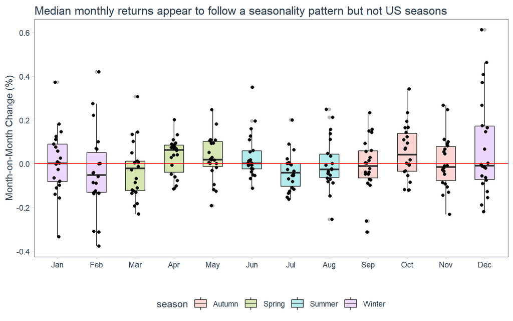

NatGas seems to exhibit a trend and seasonality after decomposiing the timeseries which could be tradable…

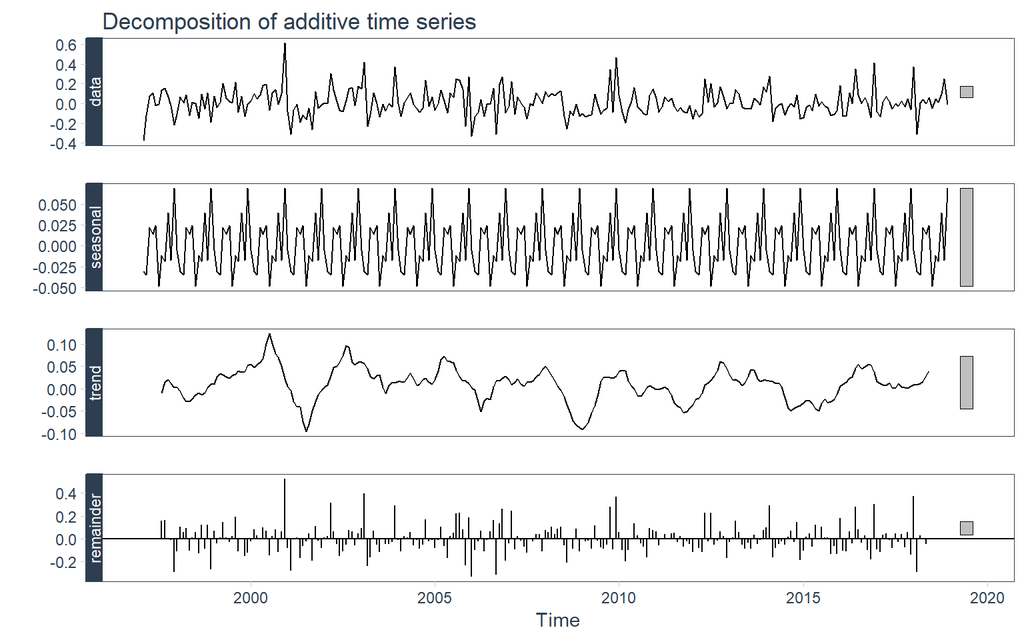

…but I’ll base the trading signal off the observed seasonality of median returns for now. Backtesting rules based on seasonality:

Short: Feb, May-Jul, Nov

Long: Mar-Apr, Aug-Oct, Dec-Jan

*Positions are placed by month end.

Looking at the backtest results, the long-short strategy have worked well in the past up until it started underperforming in mid-2012 where long-only began outperforming both long-short and short-only, and further decaying until end 2017. Short-side of the trade drove the performance decay that probably came from a demand shock (demand remained persistent despite warmer temperatures, lower warm temperatures).

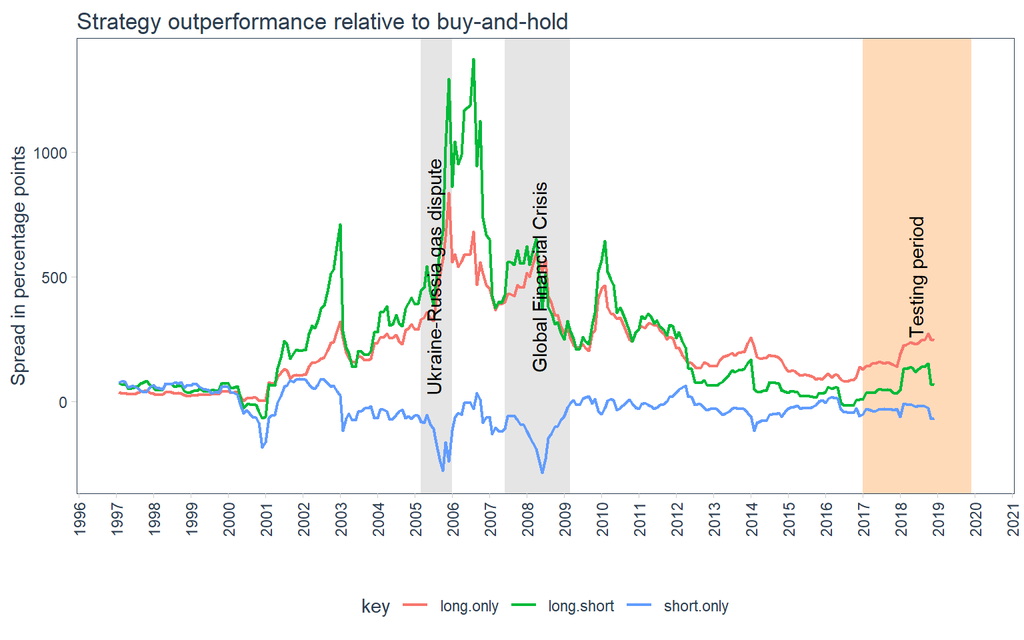

Meanwhile, long-only generated higher information ratio compared to long-short, with information ratio oscillating over time. The oscillation could be a function of sentiment or major events but this would need further research.

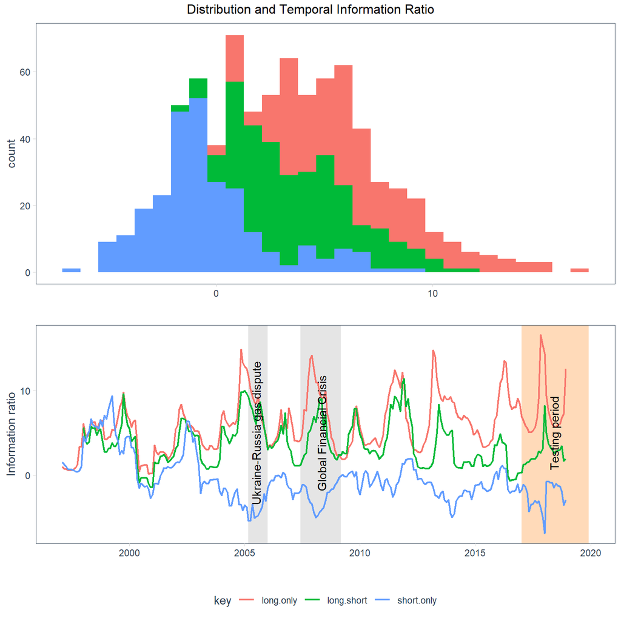

Rolling performance of all strategies vary from time to time but long-only has shown less volatile outperformance throughout the period.

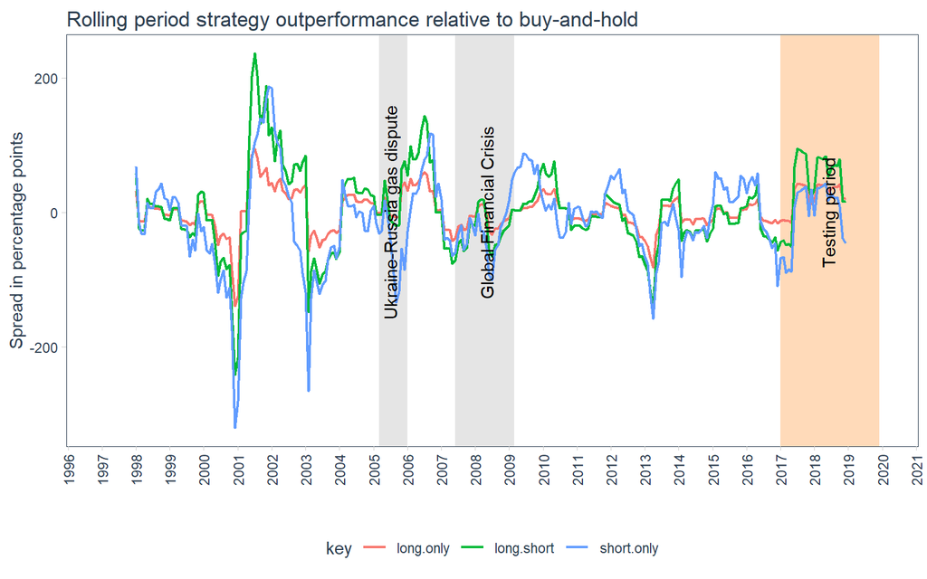

Looking at the overall strategy performances, long-short returns decayed significantly over time from 2006 until end 2016 possibly due to supply/demand shocks. On a rolling basis, long-short stated to pick up again but this is mostly from the long-side of the trade as the short-side still falls short of expectations.

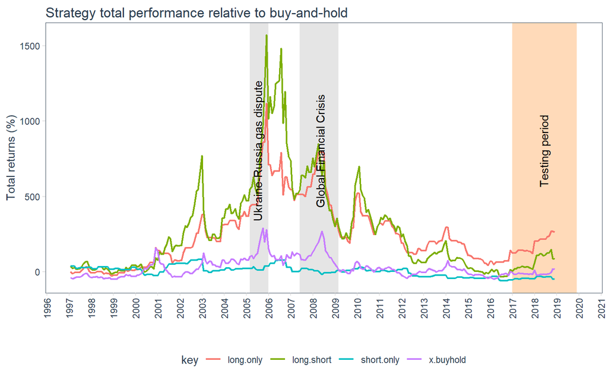

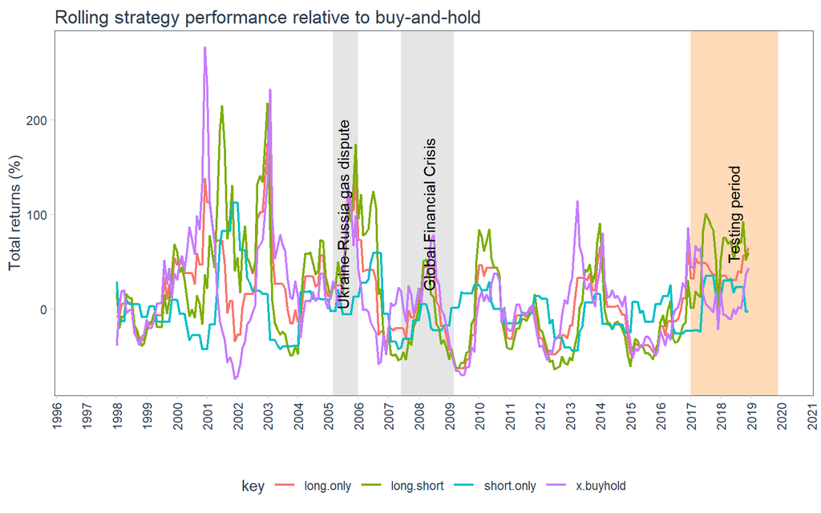

Overall, implementing a long-only strategy based on identified strong periods have generated good returns relative to long-short and short-only strategies. However, returns are significantly volatile over the testing periods, suggesting more prudent position sizing is warranted.

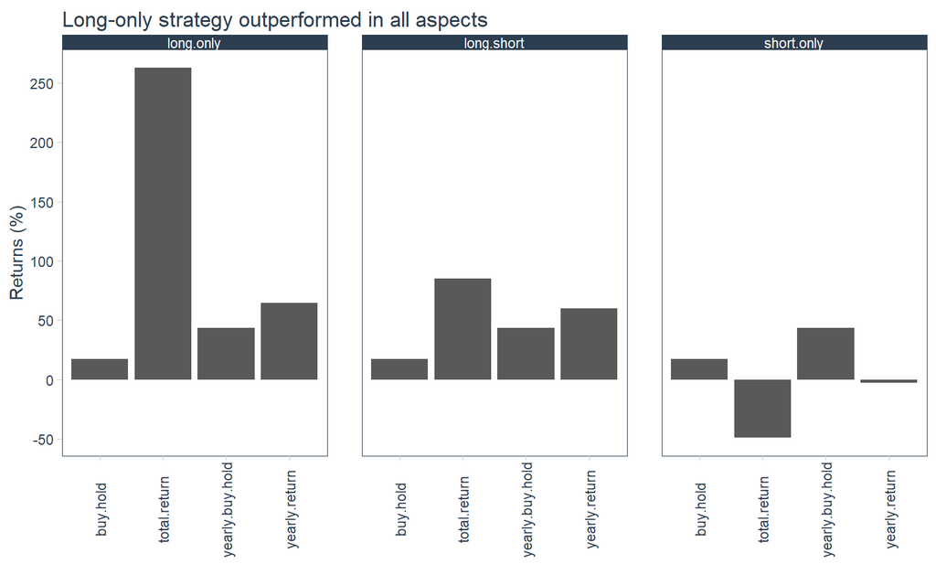